# Analyse de l’évolution des risques climatiques à floraison du blé en Limagne et identification d’une esquive phénologique optimisée

Guillaume Blanchet

2022-07-28

**Brouillon avancé. Reste à faire:**

- renforcer la revue de littérature et ajouter des références qui permettrait de justifier des choix de seuil
- ajouter références manquantes (en gras)
- réactualiser le script après avoir finaliser le script sur le sol (pour le nom des entités régionales essentiellement)
- réajuster la fenêtre de floraison potentielle ? (jusqu’au 15 juin - cas spécifique pour les cellules en altitude type chaine des puys)
- réaliser l’optimisation des paramètres variétaux avec Sirius
  - préparation des fichiers “observations”
  - lancer le modèle en mode batch…

# 1. Démarche générale et données à disposition

## 1.1 Apercu général de la démarche

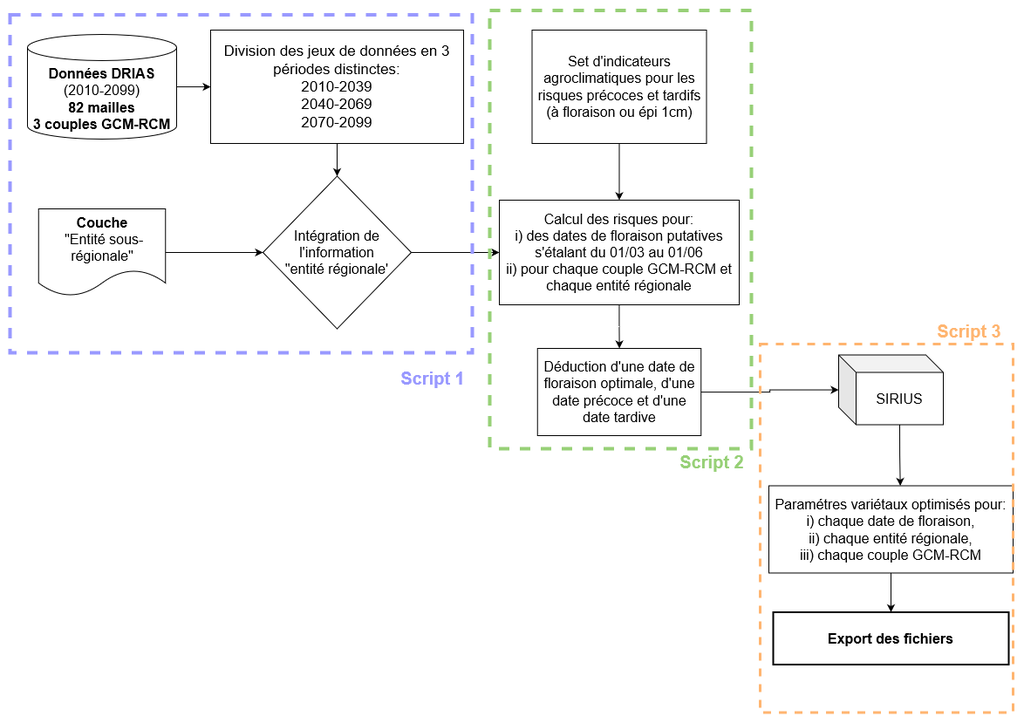

La chaine d’analyse proposée vise à :

- mieux définir les risques climatiques thermiques précoces et tardifs pour le blé tendre à l’échelle de la Limagne
- déduire des fenêtres de floraison minimisant ces risques climatiques pour le territoire de Limagne et selon différents scénarios climatiques
- mobiliser SIRIUS pour optimiser des paramétres variétaux liés à la floraison

L’idée sous-jacente à ce travail est que les variétés de blé tendre de demain ne sont pas les variétés d’aujourd’hui. Ne pouvant faire d’hypothèse raisonnable quant à des tolérances physiologiques (**e.g.** pour des stress thermiques et/ou hydriques) à venir, nous proposons de les définir uniquement sur la base d’une stratégie d’évitement des risques en jouant sur leur précocité pour la floraison.

## 1.2 Données climatiques à disposition et préparation des données

Pour chaque **cellule Safran-DRIAS** (**82** pour rappel), nous disposons de plusieurs séries climatiques…

- issues de **3 couples GCM-RCM**
- pour **3 scénarios d’émissions** (**RCP** selon le protocole CMIP5, à savoir RCP2.6, RCP4.5, RCP8.5)
- pour **3 horizons temporels** (à savoir 2010-2039 ; 2040-2069 ; 2070-2099)

### Informations spécifiques - choix des couples GCM-RCM

Parmis les couples GCM-RCM disponibles dans DRIAS (*i.e.* régionalisés à l’échelle de la France), seuls ceux avec toutes les variables nécessaires pour alimenter un modèle de culture (*i.e.* température de l’air, humidité de l’air, rayonnement incident à minima) ont été retenus. Par conséquent, les couples suivants ont été retenus:

- CRNM - ALADIN 63
- CRNM - RACMO22E
- EC-EARTH - RACMO22E

Il est important de retenir que cette restriction dans le choix des couples GCM-RCM n’est pas anodine puisqu’elle a une influence sur l’incertitude climatique considérée. Ce point est discutée dans l’analyse des données climatiques disponibles pour la Limagne (**lien** - *page non disponible pour le moment*).

### Informations spécifiques - définitions des fenêtres temporelles

A l’image des analyses climatiques proposées par DRIAS **(ajouter ici un hyperlien)**, nous proposons de considérer trois horizons temporels distincts au sein du 21ème siècle, d’une période de 30 années chacun, soit :

- un horizon proche : 2010-2039
- un horizon intermédiaire : 2040-2069
- un horizon lointain : 2070-2099

Le choix de ces horizons temporels s’appuient sur le fait que:

- ce découpage a été proposée par MétéoFrance pour représenter l’évolution des variables climatiques au cours du siècle - d’un point de vue stratégie de communication/vulgarisation des résultats, cela peut être un atout
- 30 années constitue un compromis entre le nombre de fenêtre considérées et le nombre d’années à disposition pour calculer des probabilités. Définir des génotypes dont les caractéristiques phénologiques doit reposer sur
  1. une confiance statistique (le risque climatique est suffisamment bien caractérisée)
  2. une plausibilité technique (l’intervalle de temps considéré semble adapté et justifié du point de vue développement variétal et maintien sur le marché). Sur ce dernier point, une fenêtre de 30 années semble probablement trop long, mais racourcir cette fenêtre se ferait au détriment de la confiance statistique (*à noter: nous n’avons pas retenu l’utilisation d’un générateur de climat, à l’image de LARS-WG (**ajouter un hyperlien**), mais que ce type d’outils semble particulièrement adapté pour faire face au dilemme mentionné ici*).

## 1.3 Risques climatiques considérés

### Hypothèses préalables

Notre proposition d’**analyse du risque climatique sur les performances agronomiques du blé tendre** repose sur un couplage entre

1. une **analyse des variables climatiques** disponibles et
2. des **hypothèses simples quant au fonctionnement phénologique** de la culture de blé.

Concernant, le premier aspect, nous avons choisi des **indicateurs sur la base de seuils de température** dont l’effet physiologique sur la culture est documenté dans la littérature scientifique. En particulier, nous avons considéré :

- un **risque de stress précoce**, soit :
  - les températures gélives entre le stade “épi 1 cm” et la date de floraison,
- un **risque de stress tardif**, soit :
  - les fortes températures à floraison
  - les fortes températures pendant le remplissage du grain.

**Nous avons volontairement exclu les stress hydriques**, puisqu’ils sont difficilement estimables à partir des données climatiques seules.

Pour quantifier ces risques, nous avons fait l’hypothèse que la phénologie d’une variété-type de Limagne (e.g. “Apache”) repose sur des temps thermiques relativement fixes entre les stades phénologiques suivants :

- entre le stade “épi 1 cm” et la floraison, on observe 500°C.jour (avec T_base 0)
- entre la floraison et la fin du remplissage du grain, on observe 700°C.jour (avec T_base 0)

Sur la base de ces temps thermiques, des indicateurs agroclimatiques sont établis (détaillés ci-après). On évitera de mobiliser le terme ‘indicateur écoclimatique’, puisqu’aucun modèle de phénologie/ de culture *stricto-sensu* n’ont été mobilisés pour définir la phénologie des cultures.

Il est à noter que les indicateurs agroclimatiques se distinguent par :

- l’**intensité** de l’évènement climatique considéré - les seuils d’intensité choisis reposent sur les connaissances scientifiques disponibles
- la **durée/fréquence** de l’évènement climatique considéré - peu d’information existe sur ce sujet quant à l’effet sur les performances de culture et sera principalement évalué sur la forme d’une analyse de sensibilité

### Stress précoces - risque gélif

Le seuil de létalité du blé tendre au froid gélif dépend du stade phénologique considéré. La littérature scientifique fait état des valeurs de référence suivantes :

- T° $\leq$ -10°C (**ref**)
- T° $\leq$ -4°C après épiaison ([Marcellos & Single, 1984](https://www.publish.csiro.au/fp/PP9840007))
- T° $\leq$ 9°C pendant la floraison ([Porter et Gawith, 1999](https://www.sciencedirect.com/science/article/pii/S1161030198000471))

**Paragraphe à étoffer**

Pour quantifier un risque de gel, nous avons considéré le nombre de jours entre le stade “épi 1 cm” et la floraison pour lesquels la température journalière minimale est inférieure ou égale à -4°C, soit:

$$IAC_{gel} = \sum_{t = épi\space1\space cm}^{floraison}{jour_t(T_{min}
\leq -4)} \\
où \space jour(épi \space 1 \space cm) \space = \space jour(floraison -
500°C.jour) \space$$

### Stress tardifs - excès thermiques

Pour caractériser les stress tardifs, on considère uniquement les risques thermiques au moment de la floraison et pendant la phase de remplissage des grains. La littérature scientifiques fait état des risques suivants (**revoir la littérature ici**) :

- T° $\geq$ 31°C pendant les 5 à 10 jours avant la floraison induise un taux élevé de grains stériles ([Wheeler et al., 1996b](https://academic.oup.com/jxb/article/47/5/623/514346), [Vara Prasad et al., 2017](https://www.sciencedirect.com/science/article/pii/S0378429016303835?casa_token=I4kkNovA1uAAAAAA:ogu-CB1nPt2qBRFXr1uBVHxGEjDkqOzEP9y73u_YUdDgqoCUHEVcs7Zvnq2ynY2CEKzbtVavLKMc#bib0245))
- T° $\geq$ 27°C pendant la phase de floraison
- T° $\geq$ 40°C pendant la phase de remplissage du grain ([Porter et Gawith, 1999](https://www.sciencedirect.com/science/article/pii/S1161030198000471))

Nous avons considéré deux risques d’excès thermiques, à savoir:

- un risque avant floraison, en comptant le nombre de jours où la température journalière maximale dépasse 30°C au cours des 10 jours précédents la floraison

$$IAC_{chaleur,pré-floraison} = \sum_{d = floraison -
10}^{floraison}{jour_d(T_{max} \geq 30)}$$

- un risque après floraison, en comptant le nombre de jours où la température journalière maximale dépasse {30, 35, 40}°C depuis la floraison jusqu’à la maturité du grain

$$IAC_{chaleur,post-floraison} = \sum_{d = floraison}^{fin \space
remplissage \space grain}{jour_d(T_{max} \geq 30)}$$

### Calcul de la probabilité d’incidence d’un risque climatique

Nous avons calculé le risque climatique sur une large fenêtre de jour de floraison potentiels (dont la plage considérée s’étend du 1er Mars au 1er Juin), pour :

- un jour de floraison potentiel $i$
- un horizon temporel $j$
- un scénario d’émission (RCP) $k$
- un cellule Safran-DRIAS $l$

L’estimation d’un risque climatique donné pour un jour spécifique est, dans notre cas, établi sur 90 “observations” (30 années x 3 couples GCM-RCM).

$$P_{i,j,k,l}(IAC \geq nb. \space jours) = \\
\space \\
\frac{Nb. \space d'années \space où \space IAC \space \geq seuil
\space (nb. jours) \space pour \space un \space jour \space \{i,j,k,l\}}
{Nb. \space années \space considérées \space (nb.\space modèles \space
climatique \times nb. \space années) \space dans \space l'horizon
\space \{j, k,l\}}$$

# 2. Analyse du risque climatique

Pour illustrer les analyses de risques climatiques, on considèrera uniquement les données issues de deux cellules, à savoir celles proches de Moulins (Nord du territoire considéré) et de Brioude (Sud du territoire considéré).

## 2.1. Risques précoces - gel entre épi 1 cm et floraison

Pour le risque de gel entre le stade “épi 1 cm” et floraison, la forme globale de la courbe s’apparente à une fonction logistique inverse.

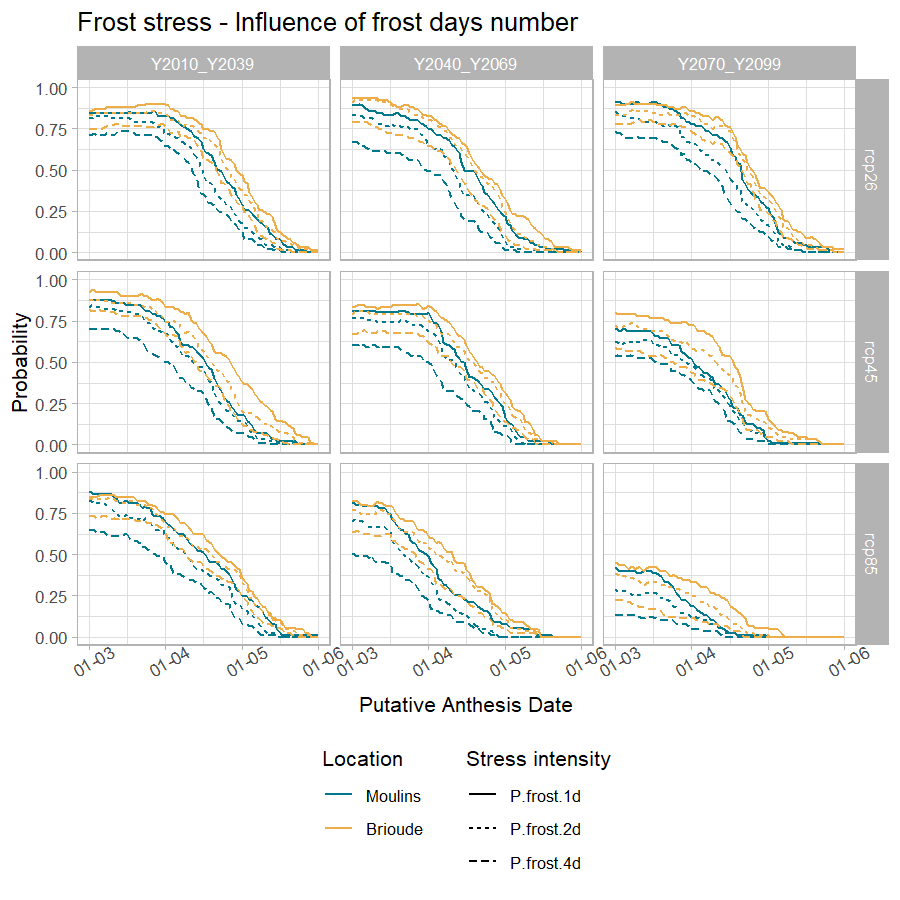

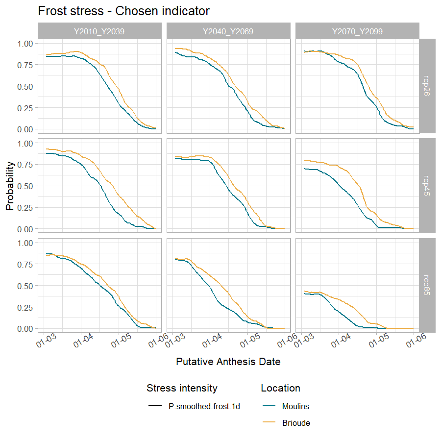

Le nombre de jours gel considérés tend à modifier la valeur de probabilité tel que:

- un plus grand nombre de jours de gel considéré tend à diminuer la probabilité la plus élevé possible (i.e. celle observée en début de saison)
- un plus grand nombre de jours de gel considéré tend à déplacer le point d’inflexion plus tôt dans la saison

Par ailleurs, on observe que :

- le risque de gel se “précocifie” au fur et à mesure que l’on évolue au sein des horizons temporels (i.e. tend à déplacer le point d’inflexion plus tôt dans la saison)
- plus le scénario climatique est pessimiste, plus il tend à diminuer la probabilité globale de risque de gel (mais sans jamais la rendre nulle)

N’ayant pas de données quant à l’effet du nombre de jour de gel sur le rendement de la culture, **on considère qu’un seul jour suffit pour réduire le rendement**.

La courbe de risque retenu est obtenu par lissage (moyenne mobile avec une fenêtre centrée symétrique de 5 jours) de la courbe obtenue en considérant :

- un **seuil thermique** fixé à **-4°C**
- un **nombre de jours considéré** fixé à **1** (entre le stade “épi 1 cm” et “floraison”)

## 2.2. Risques tardifs - en pré-floraison

Notre indicateur de risque d’accident thermique juste avant la floraison révèle la dynamique de risque suivante:

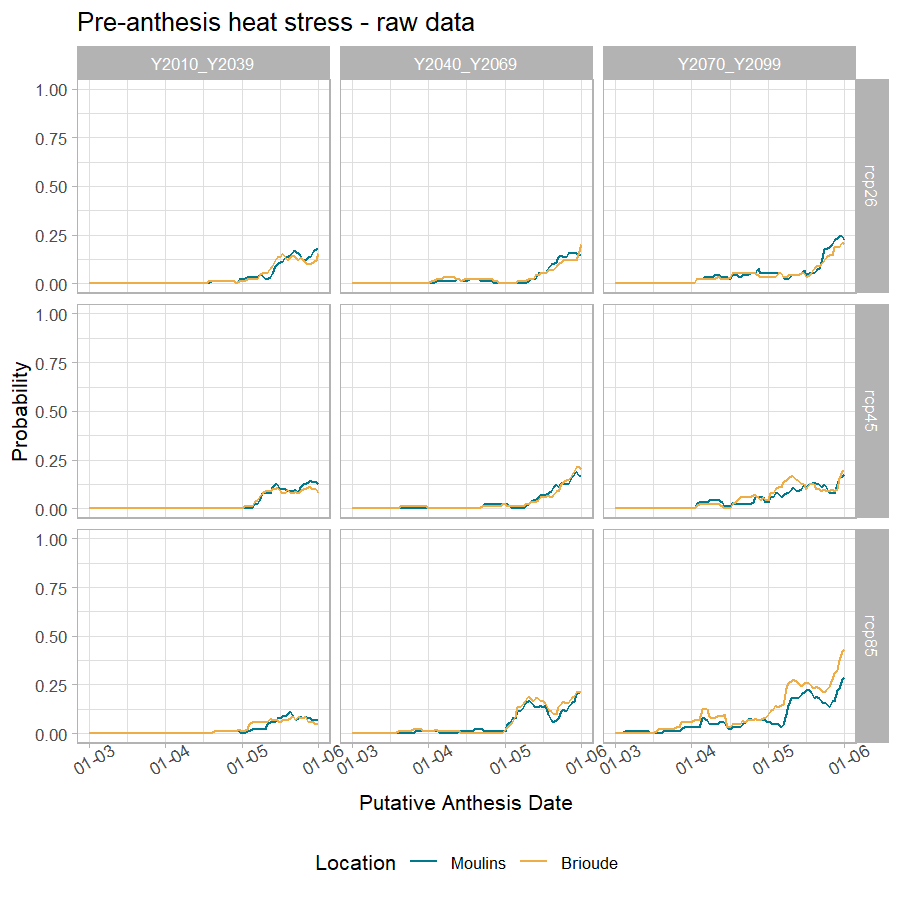

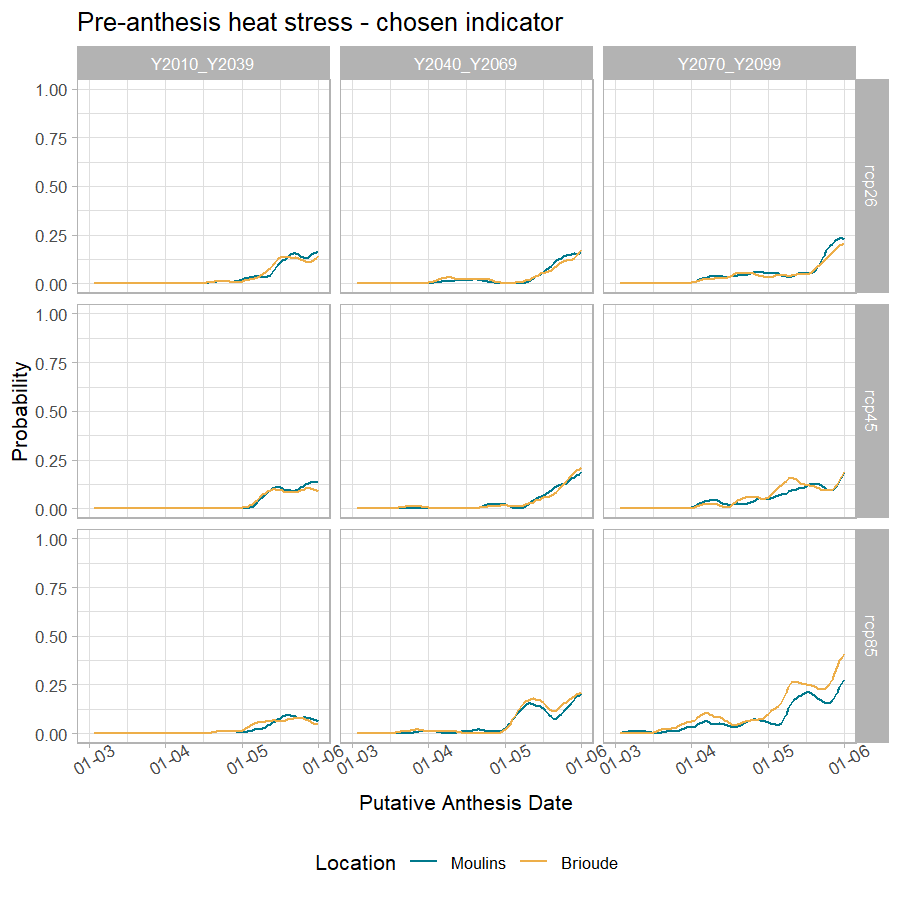

Plus la floraison est tardive, plus le risque d’un accident thermique avant floraison devient élevé. Cela devient d’autant plus marqué que le scénario climatique est pessimiste.

La courbe de risque retenu est obtenu par lissage (moyenne mobile avec une fenêtre centrée symétrique de 5 jours) de la courbe obtenue en considérant :

- un **seuil thermique** fixé à **30°C**
- un **nombre de jours considéré** fixé à **10** (avant “floraison”)

## 2.3. Risques tardifs - en post-floraison

Le risque d’excès thermique en post-floraison, la forme globale de la courbe s’apparente à une fonction logistique :

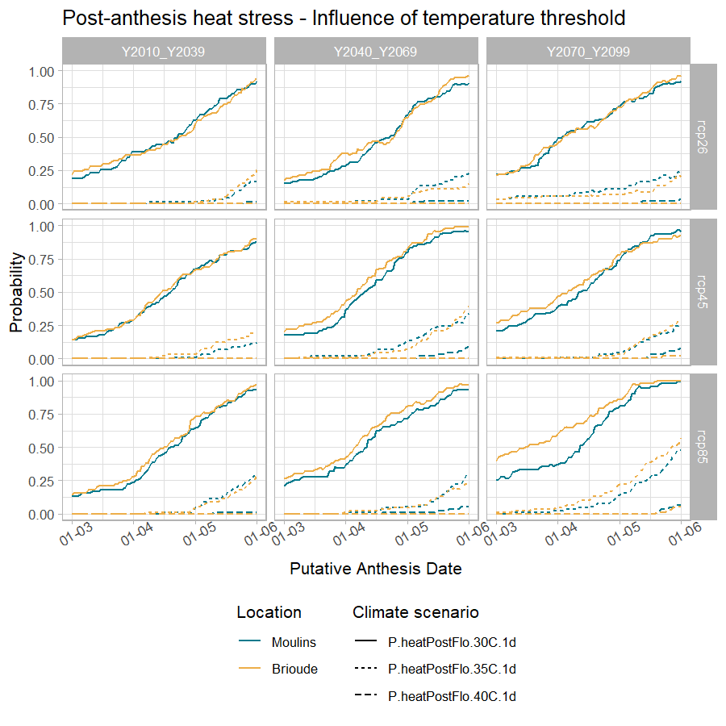

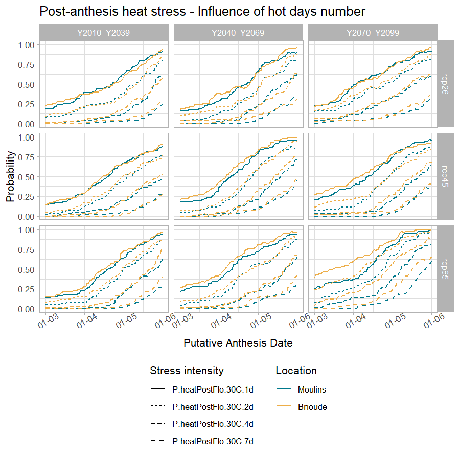

Deux effets sur le calcul de ce risque ont été évalués :

- l’influence du seuil de température choisi (30, 35 et 40°C)
- l’influence du nombre de jours “chauds” considérés (1,2,4 et 7)

Les deux aspects ont un effet considérable sur la probabilité d’occurence du risque considéré. Logiquement, plus leur valeur augmente, plus la probabilité de dépasser ce risque diminue.

D’un point de vue dynamique, le risque d’excès thermique pendant le remplissage du grain va se précocifier à l’avenir. Cela est d’autant plus marqué que le scénario climatique considéré est pessimiste.

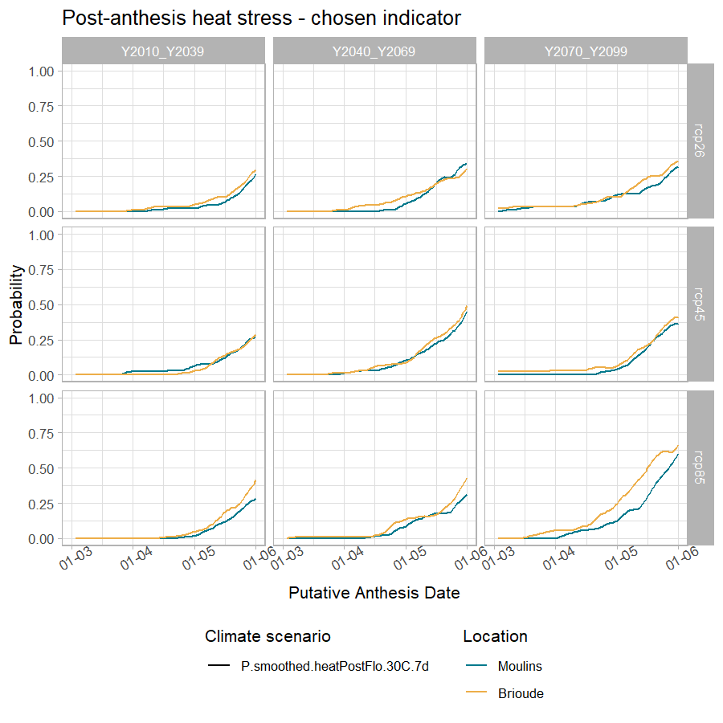

La courbe de risque retenu est obtenu par lissage (moyenne mobile avec une fenêtre centrée symétrique de 5 jours) de la courbe obtenue en considérant :

- un **seuil thermique** fixé à **30°C** (seuil marquant les premiers effets sur le remplissage du grain)
- un **nombre de jours considéré** fixé à **7** (entre la floraison et la fin du remplissage)

## 2.3 Risque climatique global et date de floraison optimal

### Approche proposée

Pour considérer un risque climatique global, on propose de la définir tel que:

$$P_{risque \space global}(d) = max\bigg(P_{gel}(d) \space ; \space
P_{chaleur, pré-floraison}(d) \space ; \space
P_{chaleur,post-floraison}(d)\bigg)$$

Visuellement, il s’agit de choisir la limite supérieure des trois courbes définies auparavant :

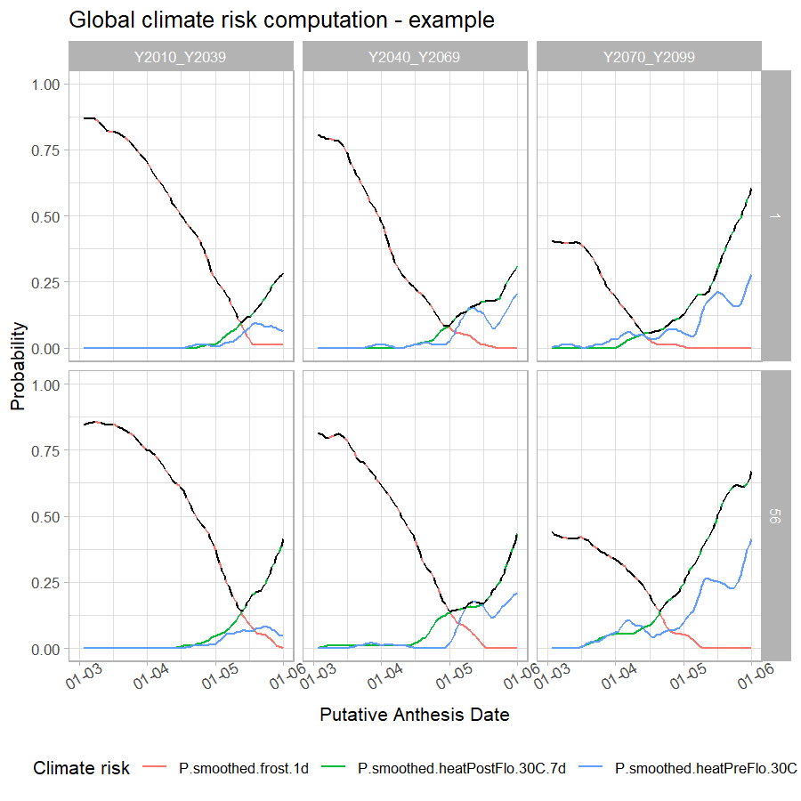

Une fois la courbe de risque climatique global définie, on définit ensuite la date de floraison optimale (*i.e.* le minimisant) tel que :

$$jour_{risque \space minimal} = médiane\Bigg( \bigg\{ jour_i =
min\bigg(P_{risque \space global}(d) \bigg) \bigg\} \Bigg)$$
On propose de mobiliser la médiane au cas où “un plateau” de valeurs minimales serait rencontré : la journée centrale (ou médiane) serait alors choisie. Visuellement, cela revient à regarder la date à laquelle la valeur minimale de la courbe est observée:

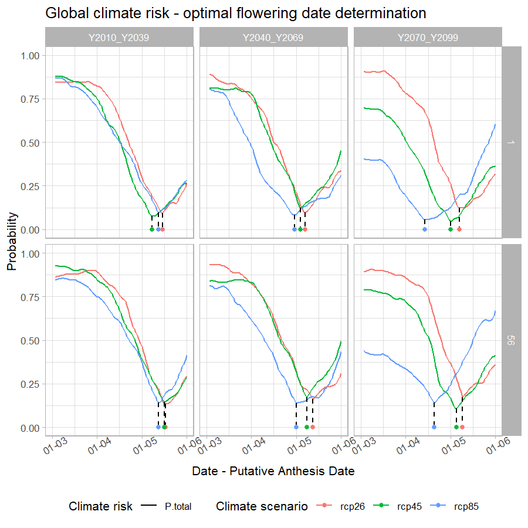

### Synthèse des jours minimisant le risque climatique pour des stress précoces et tardifs

Les dates de floraison optimales calculées sur chaque cellule semblent cohérentes au sein de chaque entité régionale. On observe globalement un gradient entre les entités en altitude (*e.g.* Chaine des Puys) et celle en plaine (*e.g.* Plaines et collines calcaires de Limagne). Le gradient Nord-Sud semble lui moins marqué (*e.g.* Plaines et Collines calcaires de Limagne *vs.* Collines du Brivadois).

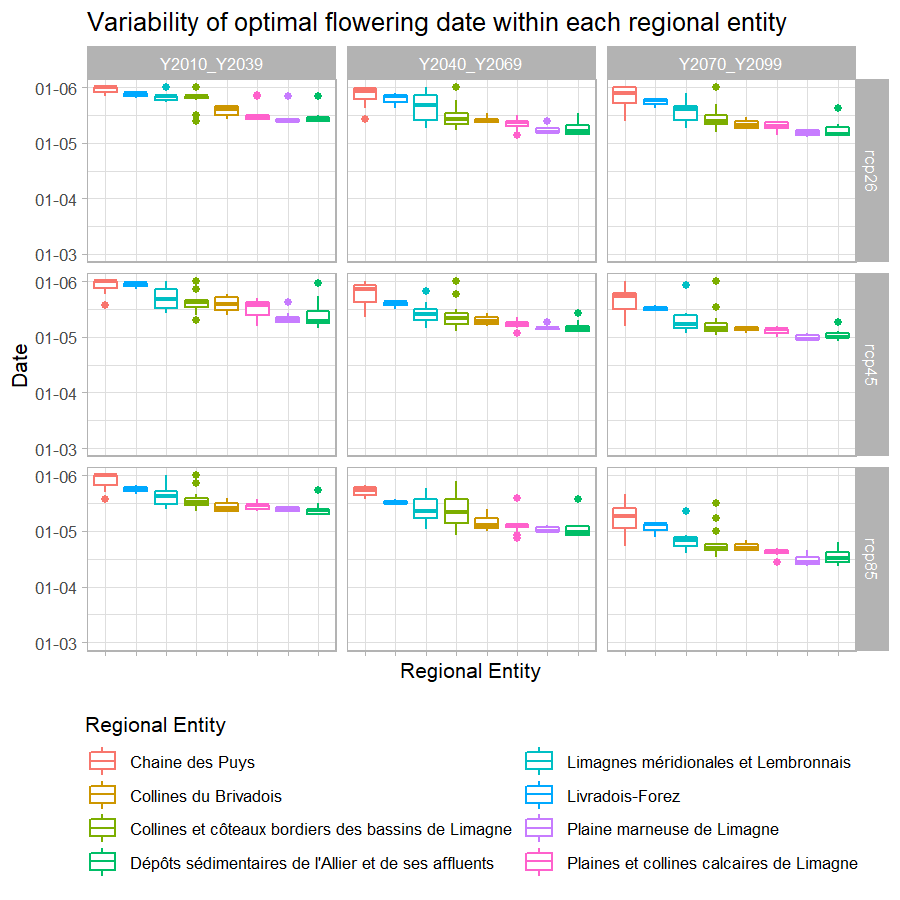